# Citi Bike NYC

Sri Seshadri

8/10/2018

# Exploratory Data analysis

The goal here is to understand the data to get an idea on what is in the data and what problems can be solved using the data in terms of:

- Inventory of bikes in stations
- Demand at stations & expected demand
- Popular routes for users
- Popular routes by user groups

# Caveat

The data spans between 2018-07-01 and 2018-08-02

## Where are the bike stations located?

The bigger the marker, the more traffic (start / stops) in the station.

[interactive chart not shown]

Though the data title says NYC, the bike stations are more in the NJ side of the state

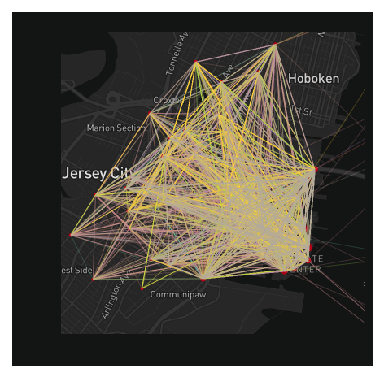

The traffic is on the stations that are to the east of NJ, near the water front. The lines were attempted to be colored by groups of customer , but the subcribers overwhelm the population.

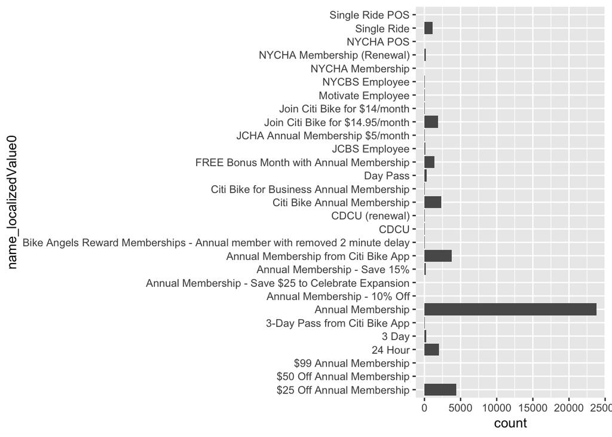

# Popular checkout times

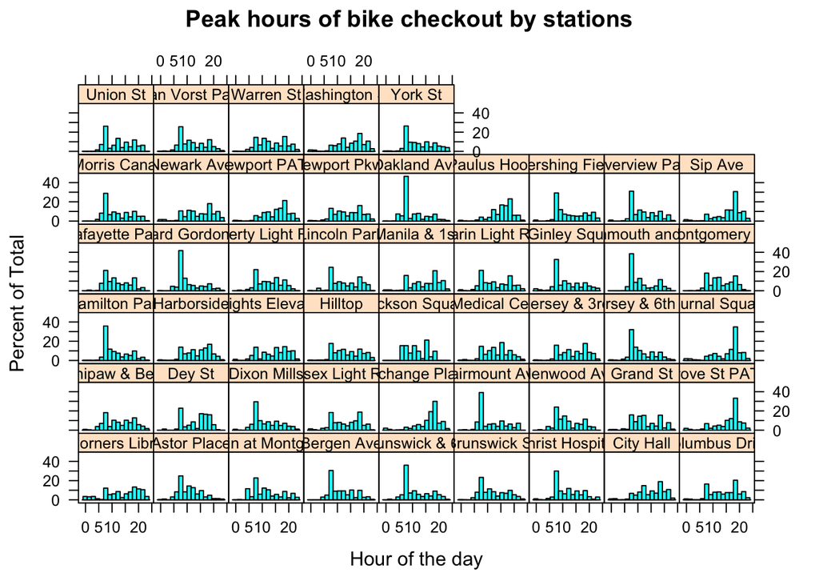

# Popular checkin times

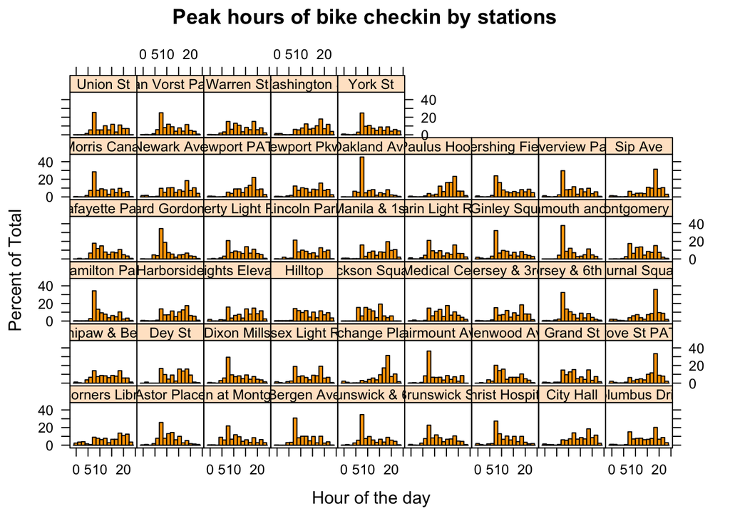

It looks like 7:30 am and 5:30 pm are the busy hours?

# Questions

- Can we focus on just the few nodes that have most of the traffic?
- Can we assume duration of the trip in the data to be directly propotional to the cost of transporting?
  - This way we don’t have to calculate the geo distances; I am sure there must be a way to calcualte if need be.

# Problem framming

- Minimize bikes
- Maximize service

# Constraints

- Pretend we can have only X number of bike stations within 2 mile radius?
- Priority for subscribers (annual)?